# Homework2.Rmd

Daniel Wu

2025-01-14

# Problem 1

## Part A

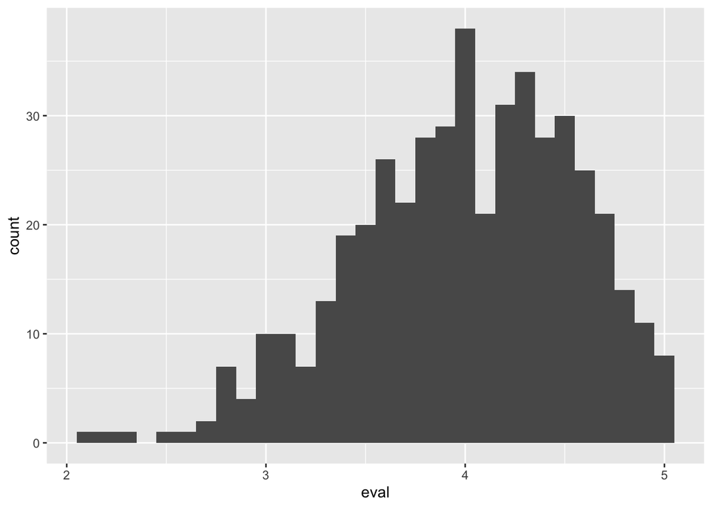

This histogram shows the distribution of course evaluation scores

The distribution seems to be skewed towards 4 out of 5 points, meaning that a lot of students were quite satisfied with their professors.

## Part B

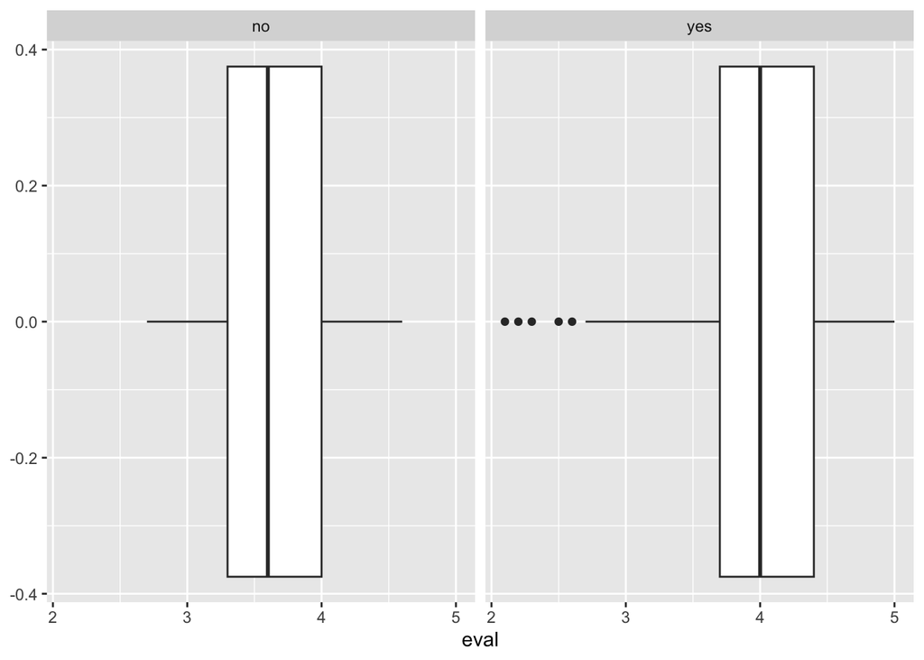

Distriution of course evaluation scores (eval) among professors who are native or non-native English speakers

## Part C

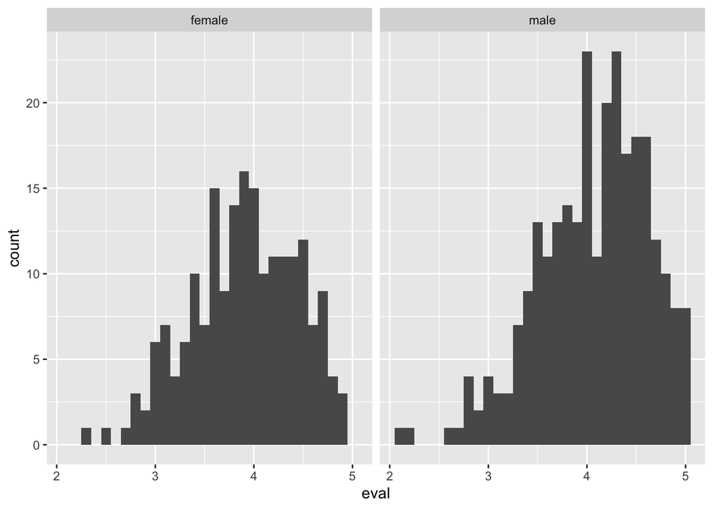

Distribution of course evaluation scores (eval) among female and male professors

According to the two histograms, the distribution of course evaluations among female and male professors look very similar. However, there is apparently a greater count of male professor when compared to female professors.

## Part D

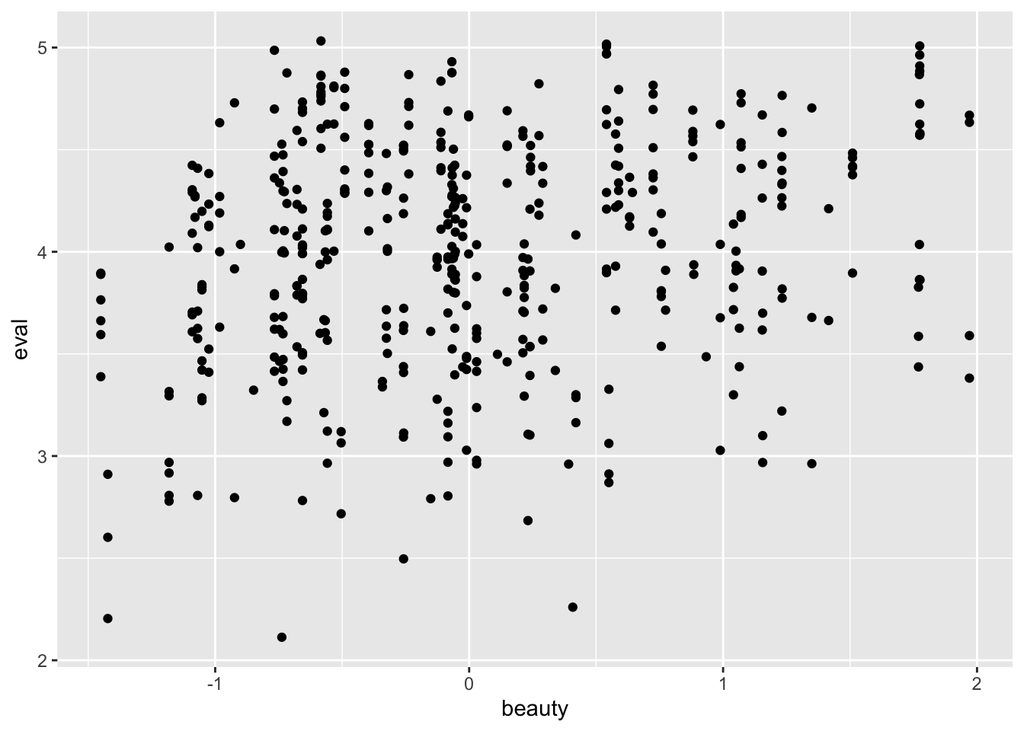

Relationship between beauty and the evaluations core of professors (eval)

This suggests that there is some positive relationship between beauty and course evaluations of professors.

# Problem 2

## Plot A

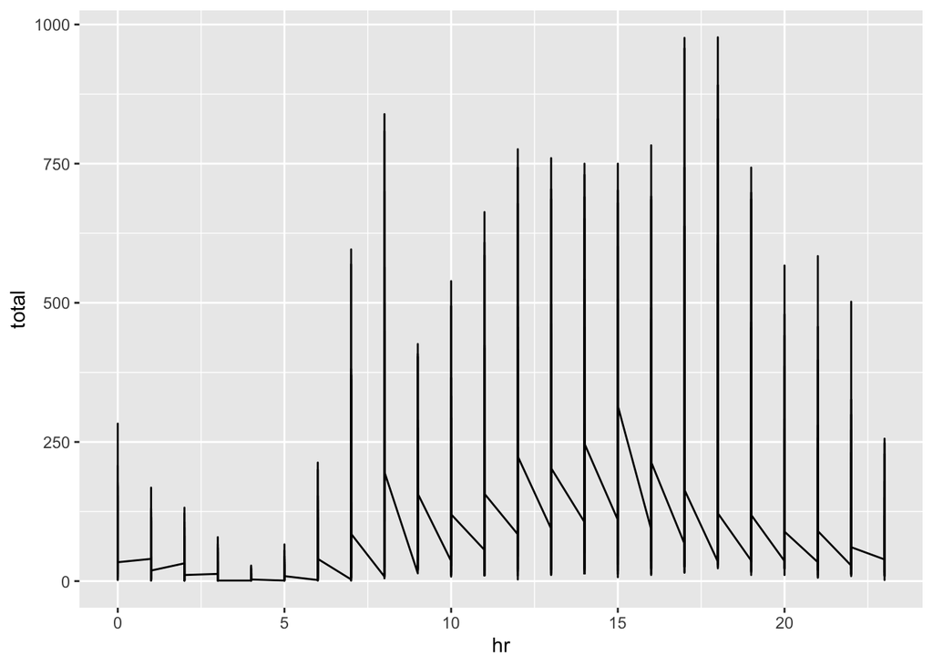

The number of bike rentals across different hours of the day

This line graph shows that in the early hours (hr) of the day, there are not a lot of bike rentals (total). However, as noon approaches, there is an increase in bike rentals, but at around 5 or 6 pm, bike rentals started to decrease again. This shows that people tend to rent less bikes when it is dark outside when compared to when it is daytime.

## Plot B

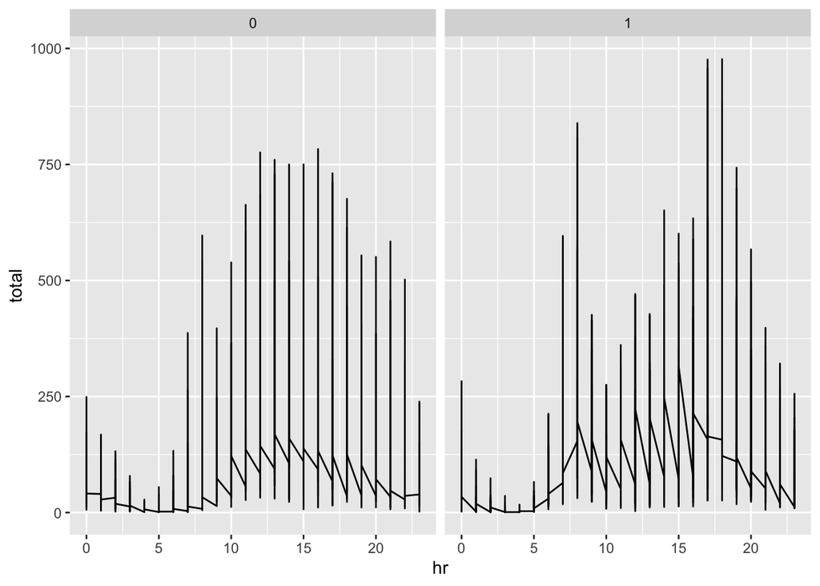

The total number of bike rentals durign the differnet hours of the day according to if it is a weekday or weekend.

## Plot C

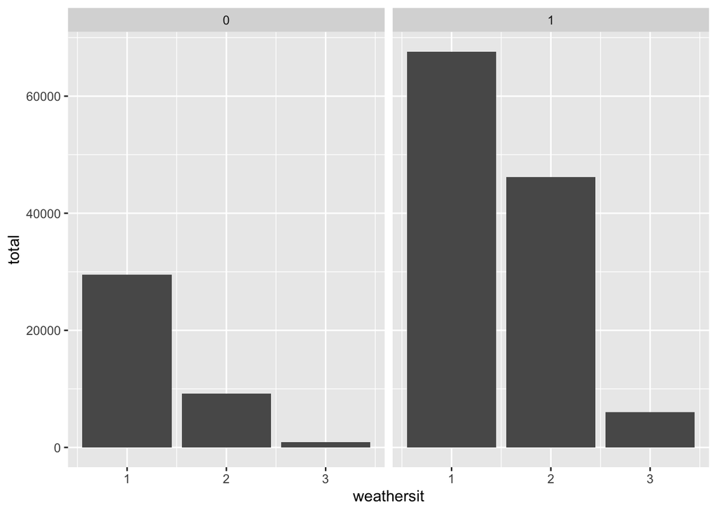

The number of bike rentals during the different weather conditions (1, 2, 3)

According to the bar plots, first of all, weather has a pretty significant effect on bike rentals (total). When the weather is good (eg. clear, sunny, partly cloudy) (1), there are many people who rent bikes. However, when the weather is poor (eg.thunderstorms/snow/fog), there is a lot less people who rented bikes. This relationship is demonstrated on both weedays (1) and weekends (0). However, the total number of people who rented bikes also increased when it is a weekday, furthering showing that some people primarily rely on bikeshare services to commute to work.

# Problem 3

## Part 1

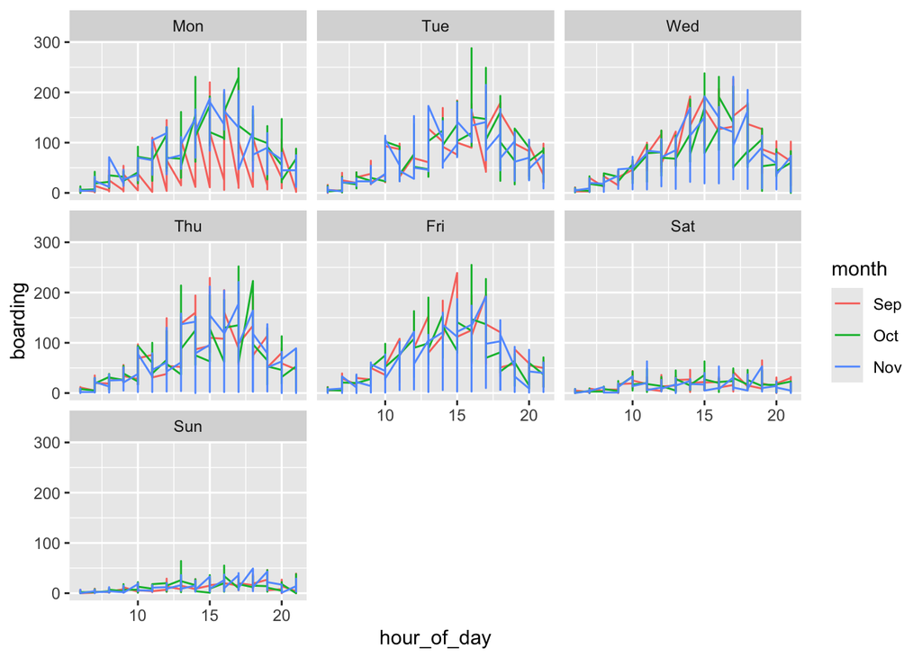

Average boarding among September, October, and November by day of the week.

The hour of peak boardings is usually between 3 and 5 pm (15 and 17), meaning that routine travel patterns (eg. school/work-related travel) peak at those hours. In September, some regions have holidays (eg. Labor Day), which potentially reduces Monday traveling. In November, average boardings seem lower on Wednesdays, Thursdays, and Fridays due to Thanksgiving, which can lead to reduced local commuting.

## Part 2

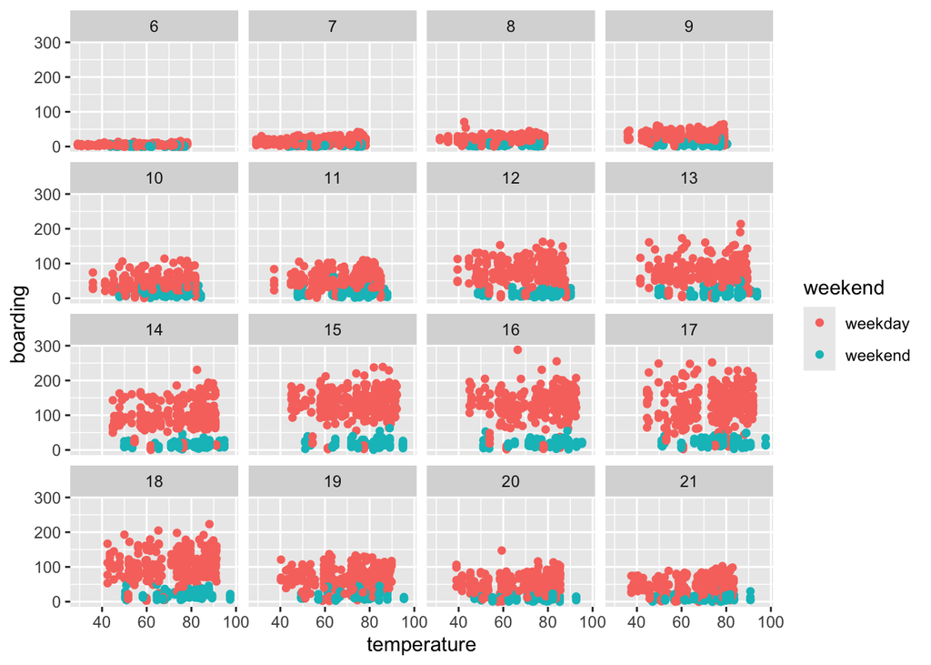

The scatter plot shows the the number of boardings during the weekdays or weekends among the hour of the day at different temperatures.

# Problem 4

## Part A

```
## # A tibble: 10 × 3
##    performer                                 song                          count
##    <chr>                                     <chr>                         <int>
##  1 Imagine Dragons                           Radioactive                      87
##  2 AWOLNATION                                Sail                             79
##  3 Jason Mraz                                I'm Yours                        76
##  4 The Weeknd                                Blinding Lights                  76
##  5 LeAnn Rimes                               How Do I Live                    69
##  6 LMFAO Featuring Lauren Bennett & GoonRock Party Rock Anthem                68
##  7 OneRepublic                               Counting Stars                   68
##  8 Adele                                     Rolling In The Deep              65
##  9 Jewel                                     Foolish Games/You Were Meant…    65
## 10 Carrie Underwood                          Before He Cheats                 64
```

This table shows the top 10 songs on Billboard Top 100

## Part B

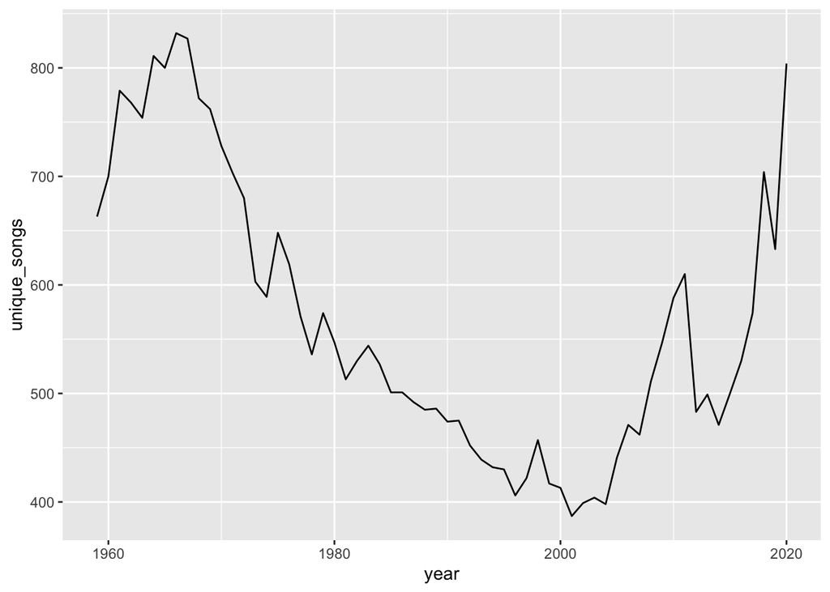

Number of unique songs appearing at any position on the Billboard Top 100 chart in any week in a year.

According to this line graph, the number of unique songs on the Billboard Top 100 peaked in the mid-1960s, and then rapidly declined unill around 2003. Then, it started to rapidly increase again, reachin a level near the mid-60s peak in 2020.

## Part C

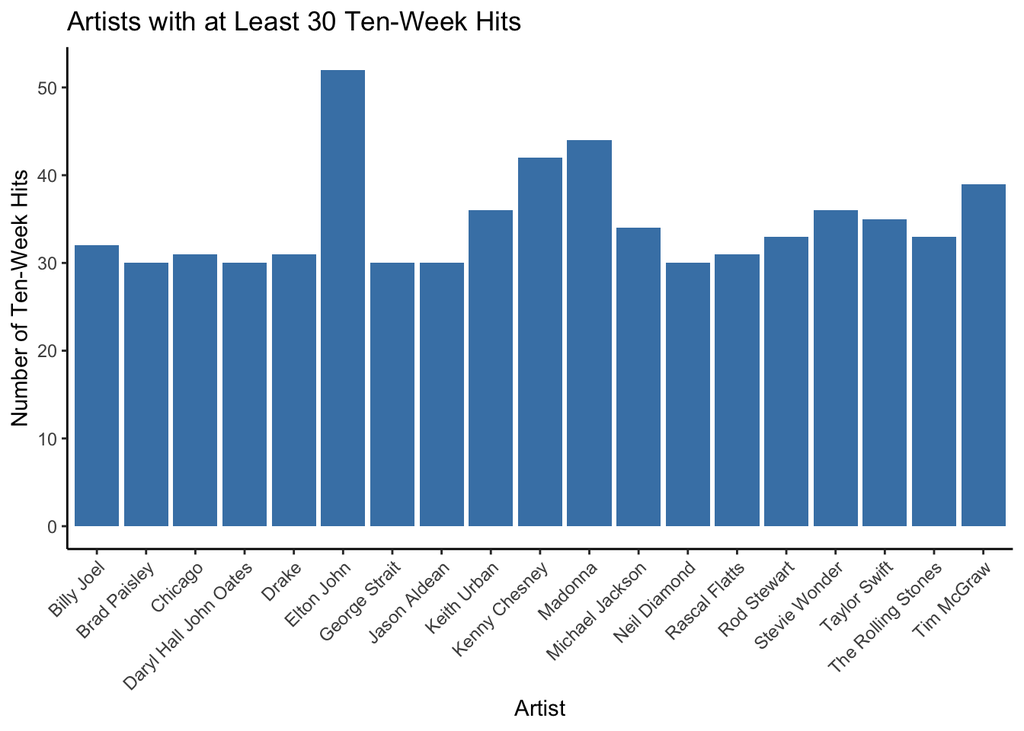

The number of ten-week hits among the artists with at least 30 ten-week hits